# Capstone Project - The Battle of Neighborhoods (Week 2)

[figure not shown]

# Social centers in Rome

## Table of contents:

- Introduction
- Background
- Data
- Methodology
- Results
- Discussion
- Conclusions
- References/acknowledgments

## **Introduction**

Suppose a social cooperative providing social services for the city of Rome (Italy)

This organization is in charge by Rome's administration to supply services to prevent youth discomfort.

They decided to open social centers in various locations of the city, to provide places where young people can meet and find informations and support

Due to **budget limitations**, the organization needs to find the areas of the city where this service is needed the most, in order to concentrate their limited financial rescources.

So they reached our Data Science Team and toghether we decided to work on the following **question**:

*Can we find Rome's neighboroods where a social center is most needed?*

As we will see in more details in the *Results* section, we will be able to:

- identify a big cluster of zones with highest discomfort profile (60 zones out of 155)
- suggest the following 5 zones to start our customer's project:
  - S. Alessandro
  - Magliana
  - Barcaccia
  - Infernetto
  - Lucrezia Romana

## **Background**

Rome is the capital and biggest city of Italy, with a population of 2,808,293 at 01.01.2021 (source: www.istat.it) and a territory of 1,285 km²

It has several administrative subdivision; one of them is the subdivion in "Zone urbanistiche di Roma" ("Rome's urbanistic zones"), which can approximate the concept of neighborhood, establised in 1977 for statistical and territorial planning reasons. This divides Rome's territory in 155 Zones (= Neighborhoods), grouped in 15 "Municipi" (=Boroughs)

You can find more on Wikipedia: https://it.wikipedia.org/wiki/Zone_urbanistiche_di_Roma (I apologize for been only in italian) and on google maps: https://www.google.com/maps/d/u/0/viewer?mid=1E4TpQ9oftDIBneEK4KzDFwQfbvQ&ll=41.89062981328977%2C12.346966041866727&z=11

The following image (taken from Wikipedia page) shows the map of Rome's urbanistic zones

[figure not shown]

Rome's urbanistic zones

For the objective of our analyses, we look for a method to create "*profiles*" of Rome's neighborhoods, such that we can create groups (*clusters*) of neighborhoods which are similar with respect of:

- socio-demographic factors: economic and social situation can be seen as a factor of discomfort, so we want a neighborhood's profile to take account of it
- density of venues: shortage of venues where people can meet (including bars, restaurants, cinemas, theatres, museums, and so on) can motivate the needing of a social center as an alternative for young people

The underlying idea is that if we can find the clusters where the above-mentioned factors are low, than those neighborhoods that belong to these clusters are those who requires our service the most

## **Data**

As stated in the background section, we need both socio-demographic and location data

**1. socio-demographic data**

For this category of data, we can rely on a [paper](https://www.istat.it/it/files//2017/01/C-allegato-statistico24_01_17_REV.pdf) from Italian National Institute of Statistics (*"Istat"*)

This paper reports a set of socio-economic indicators for all of the 155 Zones of Rome. It's available only in PDF format from ISTAT's site, but we can leverage tabular-py Python's library to scape the tables of data from the document (https://pypi.org/project/tabula-py/)

The document in only in Italian, but We'll provide description of all relevant features.

In this image we show a preview of the data available in the paper:

[figure not shown]

In the first column, we find the name of each zone (in the image we see only the first zones in alphabetical). Subsequent columns represent an indicator that we will map to a feature in a Pandas data frame:

- Surface (squared km)
- Population
- Pop0-14 (Population with age less or equal 14 years)
- Foreigners (Number of)
- Centrality index (ratio between exiting commuters and incoming commuters)
- Old Age Index (Population 65+ old over total population)
- School Dropout Rate
- Unemployment Rate
- Neet Rate (Percentage of population aged 15-29 not working, not studying, not looking for a job)
- Economic Discomfort Index (Percentage of families with sons, with no member with a job)
- Cultural Emplyees Index

(Note: data from 2011 Italian Census)

**2. location data**

for this category of data, we can leverage Foursquares APIs in order to retrieve:

- venues in every neighborhood, using the `explore` endpoint and the coords retrieved on previews step
- category of each venue from the response, in order to build the venues profile of each neighborhood
- as we are not intrested in detailed venues categories, we will perform our analysis on macro-categories of venues, as defined on [Foursquare categories page](https://developer.foursquare.com/docs/build-with-foursquare/categories/)
- for geo-localization of the zones, we will use the shapefiles of Rome's territory provided by the web-site #mapparoma: https://www.mapparoma.info/zone-urbanistiche/, witch we will handle through [geopandas](https://geopandas.org/) geo-spatial plotting library and [folium](https://python-visualization.github.io/folium/)

## **Methodology**

### Required libraries

```python
# data wrangling
import pandas as pd
import numpy as np
import pickle
from collections import Counter
# scraping
import json
import requests
import re
from bs4 import BeautifulSoup
import tabula
# clustering
from sklearn.cluster import KMeans
from sklearn.preprocessing import StandardScaler
from sklearn.metrics import silhouette_score
# plotting and visualization
import matplotlib.pyplot as plt
import seaborn as sns
import geopandas as gpd
import folium
```

```python
%matplotlib inline
```

```python
pd.set_option('display.float_format', lambda x: '%.2f' % x)
```

### Extraction of socio-demographic data

(*credits: Istat - Italian institute of statistics* www.istat.it)

```python
file = 'https://www.istat.it/it/files//2017/01/C-allegato-statistico24_01_17_REV.pdf'
# using tabula-py read_pdf method to scrape the PDF (returns a list of pandas dataframes, one for each table in document )
tables = tabula.read_pdf(file, pages = "18-23", multiple_tables = True)

#adjust scraped tables and append to a single dataframe
col_names = ['Name', 'Surface', 'Population','Pop0-14', 'Foreigners','Centrality Index', 'Old Age Index', 'Foreigner Rate', 'School Dropout Rate','Unemployment Rate', 'Neet Rate','Economic Discomfort Index', 'Cultural Employees Index', 'Sections Number']
urban_zones_df = pd.DataFrame(columns=col_names)

wrong_col = 'Unnamed: 0'
for i, df in enumerate(tables):
    if wrong_col in df.columns:
        df = df.drop([wrong_col], axis=1)
    df.columns = col_names
    urban_zones_df = urban_zones_df.append(df[5:], ignore_index = True)

urban_zones_df = urban_zones_df[:-3]
```

```python
urban_zones_df.head()
```

[output not shown]

```python
# format conversion
urban_zones_df['Surface'] = urban_zones_df['Surface'].str.replace(',','.').astype(float)
urban_zones_df['Population'] = urban_zones_df['Population'].str.replace('.','').astype(int)
urban_zones_df['Pop0-14'] = urban_zones_df['Pop0-14'].str.replace('.','').astype(int)
urban_zones_df['Foreigners'] = urban_zones_df['Foreigners'].str.replace('.','').astype(int)
urban_zones_df['Centrality Index'] = urban_zones_df['Centrality Index'].str.replace(',','.').astype(float)
urban_zones_df['Old Age Index'] = urban_zones_df['Old Age Index'].str.replace(',','.').astype(float)
urban_zones_df['Foreigner Rate'] = urban_zones_df['Foreigner Rate'].str.replace(',','.').astype(float)
urban_zones_df['School Dropout Rate'] = urban_zones_df['School Dropout Rate'].str.replace(',','.').astype(float)
urban_zones_df['Unemployment Rate'] = urban_zones_df['Unemployment Rate'].str.replace(',','.').astype(float)
urban_zones_df['Neet Rate'] = urban_zones_df['Neet Rate'].str.replace(',','.').astype(float)
urban_zones_df['Economic Discomfort Index'] = urban_zones_df['Economic Discomfort Index'].str.replace(',','.').astype(float)
urban_zones_df['Cultural Employees Index'] = urban_zones_df['Cultural Employees Index'].str.replace(',','.').astype(float)
urban_zones_df = urban_zones_df.drop(['Sections Number'],axis=1)
```

#### We have missing values on some records

```python
urban_zones_df[urban_zones_df['Economic Discomfort Index'].isnull()]
```

|  | Name | Surface | Population | Pop0-14 | Foreigners | Centrality Index | Old Age Index | Foreigner Rate | School Dropout Rate | Unemployment Rate | Neet Rate | Economic Discomfort Index | Cultural Employees Index |
| --- | --- | --- | --- | --- | --- | --- | --- | --- | --- | --- | --- | --- | --- |
| 6 | Appia Antica Nord | 20.50 | 2389 | 306 | 475 | nan | nan | nan | nan | nan | nan | nan | nan |
| 7 | Appia Antica Sud | 10.60 | 642 | 127 | 135 | nan | nan | nan | nan | nan | nan | nan | nan |
| 25 | Castel Fusano | 12.20 | 1385 | 214 | 101 | nan | nan | nan | nan | nan | nan | nan | nan |
| 26 | Castel Porziano | 61.50 | 151 | 23 | 10 | nan | nan | nan | nan | nan | nan | nan | nan |
| 35 | Ciampino | 3.00 | 80 | 19 | 8 | nan | nan | nan | nan | nan | nan | nan | nan |
| 70 | Martignano | 10.90 | 12 | 1 | 4 | nan | nan | nan | nan | nan | nan | nan | nan |
| 123 | Tor di Valle | 3.00 | 9 | 1 | 6 | nan | nan | nan | nan | nan | nan | nan | nan |
| 147 | Verano | 1.50 | 226 | 7 | 8 | nan | nan | nan | nan | nan | nan | nan | nan |
| 148 | Villa Ada | 2.90 | 825 | 113 | 139 | nan | nan | nan | nan | nan | nan | nan | nan |
| 149 | Villa Borghese | 1.40 | 473 | 52 | 91 | nan | nan | nan | nan | nan | nan | nan | nan |
| 150 | Villa Pamphili | 2.10 | 229 | 1 | 108 | nan | nan | nan | nan | nan | nan | nan | nan |

#### these are very small or low-population zones:

```python
urban_zones_df[urban_zones_df['Economic Discomfort Index'].isnull()]['Population'].sum()
```

```
6421
```

#### these zones are relative to 6.421 residents (~0.2% of total population). So we decide to drop them from the dataset

```python
urban_zones_df = urban_zones_df.dropna()
```

### Extract geografical coordinates

(*credits*: https://www.mapparoma.info/zone-urbanistiche/)

#### Using *geopandas* library

```python
shapefile = "zip:///home/michele/battle_of_neighborhoods_w1/ZU_shapefile.zip"
gdf = gpd.read_file(shapefile)

gdf = gdf.to_crs(epsg=4326)

# tweaking zone names
gdf['Name'].where(gdf['Name']!='Centro Direz. Centocelle','Centro Direzionale Centocelle',inplace=True)
gdf['Name'].where(gdf['Name']!='Grotta Rossa Est','Grottarossa Est',inplace=True)
gdf['Name'].where(gdf['Name']!='Grotta Rossa Ovest','Grottarossa Ovest',inplace=True)
gdf['Name'].where(gdf['Name']!='Mezzocamino','Mezzocammino',inplace=True)
gdf['Name'].where(gdf['Name']!='S. Maria della Pieta','S. Maria della Pietà',inplace=True)
gdf['Name'].where(gdf['Name']!='Universita','Università',inplace=True)
```

```python
# calculate centroids
zones_centroids = gdf.centroid
centroids_lon = [c.coords.xy[0][0] for c in zones_centroids]
centroids_lat = [c.coords.xy[1][0] for c in zones_centroids]
urban_zones_coords = pd.DataFrame(zip(gdf['Name'], centroids_lat, centroids_lon), columns = ['Name', 'Latitude', 'Longitude'])
# join dataframes
zones_df = urban_zones_df.merge(urban_zones_coords, how='inner', left_on='Name', right_on='Name')
```

### Extract venues with Foursquare APIs

```python
# Foursquare credentials and constants
CLIENT_ID = 'ELCGO4JTDN3CY4NULPEECJK2GBOEG5QY3HV2VZBKVQV2JFWM' # your Foursquare ID
CLIENT_SECRET = 'GIZWPHWRTEMWAPRMK0FBATZZI2AXJCOQ54FUPDI05LL0FAO0' # your Foursquare Secret
ACCESS_TOKEN = '23AO4TFOWEVEPLDSO2VRJY334SAAFJ3E1QNIH30AFYIHAMHL' # your FourSquare Access Token
VERSION = '20210221'
LIMIT = 200
RADIUS = 1000
```

```python
# create a dataframe of macro categories for venues categories aggregation
url = 'https://api.foursquare.com/v2/venues/categories?client_id={}&client_secret={}&v={}&limit=100' \
      .format(CLIENT_ID, CLIENT_SECRET, VERSION)
results = requests.get(url).json()
macro_categories_df = pd.json_normalize(results['response']['categories'])
```

```python
# function for expanding the sub-categories
def expand(l, c, d):
    d[c] = c #always add macro as sub-cat
    for i in l:
        if len(i['categories']) > 0:
            d[i['name']] = c
            expand(i['categories'], c, d)
        else:
            d[i['name']] = c #print("".format(i['name']))
```

```python
# dictionary of sub-cats with macro category
macros = {}
for categories, name in zip(macro_categories_df['categories'], macro_categories_df['name']):
    expand(categories, name, macros)
```

```python
# populate dataframe of venues data
venues_df = pd.DataFrame(columns=['name','categories', 'macros'])
for name, lat, lon in zip(zones_df['Name'], zones_df['Latitude'], zones_df['Longitude']):
    print(name)
    dict_row = {}
    url = 'https://api.foursquare.com/v2/venues/explore?client_id={}&client_secret={}&ll={},{}&v={}&radius={}&limit={}&sortByDistance=1' \
      .format(CLIENT_ID, CLIENT_SECRET, lat, lon, VERSION, RADIUS, LIMIT)
    results = requests.get(url).json()
    items = results['response']['groups'][0]['items']
    categories_list = [item['venue']['categories'][0]['name'] for item in items]
    dict_row['name'] = name
    dict_row['categories'] = Counter(categories_list)
    macros_list = [macros[cat] for cat in categories_list]
    dict_row['macros'] = Counter(macros_list)
    venues_df = venues_df.append(dict_row, ignore_index = True)
```

```python
# create a dataframe for venues macro-categories
venues_macro_df = venues_df[['name']].copy()

for macro in macro_categories_df['name']:
    venues_macro_df[macro] = 0.0
venues_macro_df = venues_macro_df.set_index('name')

for name, macros in zip(venues_df['name'], venues_df['macros']):
    for cat, cnt in macros.items():
        venues_macro_df.loc[name, cat] = cnt

venues_macro_df['Total Venues'] = venues_macro_df.apply(sum, axis = 1)
```

```python
# normalize column names and indices
zones_df = zones_df.rename({'Name':'name'}, axis=1)
zones_df.set_index(['name'], inplace=True)
# create a final df
final_df = pd.concat([zones_df, venues_macro_df],axis=1,join='inner')
final_df.head()
```

| name | Surface | Population | Pop0-14 | Foreigners | Centrality Index | Old Age Index | Foreigner Rate | School Dropout Rate | Unemployment Rate | Neet Rate | ... | College & University | Event | Food | Nightlife Spot | Outdoors & Recreation | Professional & Other Places | Residence | Shop & Service | Travel & Transport | Total Venues |
| --- | --- | --- | --- | --- | --- | --- | --- | --- | --- | --- | --- | --- | --- | --- | --- | --- | --- | --- | --- | --- | --- |
| Acilia Nord | 9.20 | 26023 | 4241 | 2008 | 0.20 | 100.20 | 77.20 | 2.10 | 12.40 | 10.90 | ... | 0.00 | 0.00 | 3.00 | 0.00 | 0.00 | 0.00 | 0.00 | 1.00 | 0.00 | 4.00 |
| Acilia Sud | 7.10 | 23640 | 3797 | 1833 | 0.70 | 107.30 | 77.50 | 2.70 | 12.00 | 11.30 | ... | 0.00 | 0.00 | 8.00 | 1.00 | 1.00 | 0.00 | 0.00 | 1.00 | 0.00 | 12.00 |
| Acqua Vergine | 11.30 | 5355 | 1033 | 487 | 0.80 | 48.20 | 90.90 | 2.20 | 7.80 | 10.90 | ... | 0.00 | 0.00 | 1.00 | 0.00 | 0.00 | 0.00 | 0.00 | 0.00 | 1.00 | 3.00 |
| Acquatraversa | 1.40 | 8689 | 1266 | 678 | 0.30 | 129.20 | 78.00 | 1.10 | 6.10 | 7.20 | ... | 0.00 | 0.00 | 1.00 | 0.00 | 5.00 | 0.00 | 0.00 | 1.00 | 2.00 | 9.00 |
| Aeroporto dell' Urbe | 4.40 | 1924 | 247 | 172 | 11.00 | 172.10 | 89.40 | 1.60 | 11.80 | 10.00 | ... | 0.00 | 0.00 | 1.00 | 1.00 | 1.00 | 0.00 | 0.00 | 0.00 | 3.00 | 6.00 |

5 rows × 25 columns

#### Some feature engineering

- Compute venues data as number of venues per 1,000 residents
- compute Pop0-14 as Index per 1,000 residents

```python
venues_features = final_df.columns[14:25]

for feature in venues_features:
    final_df[feature] = 1000 * final_df[feature] / final_df['Population']

final_df['Pop0-14'] = 1000 * final_df['Pop0-14'] / final_df['Population']
```

### Exploratory Data Analysis

Compute some descriptive statiscs and show some visualization

#### **Socio-demographic features**

```python
social_features = [f for f in final_df.columns if f not in venues_features]
social_features.remove('Latitude')
social_features.remove('Longitude')

socio_df = final_df[social_features]

socio_df.describe()[1:]
```

|  | Surface | Population | Pop0-14 | Foreigners | Centrality Index | Old Age Index | Foreigner Rate | School Dropout Rate | Unemployment Rate | Neet Rate | Economic Discomfort Index | Cultural Employees Index |
| --- | --- | --- | --- | --- | --- | --- | --- | --- | --- | --- | --- | --- |
| mean | 8.04 | 18128.08 | 137.79 | 1551.05 | 3.29 | 163.38 | 90.51 | 2.39 | 9.33 | 10.42 | 2.22 | 6.07 |
| std | 12.07 | 13982.91 | 28.84 | 1665.40 | 9.00 | 70.01 | 58.52 | 1.38 | 3.24 | 5.42 | 0.89 | 15.81 |
| min | 0.50 | 240.00 | 65.18 | 17.00 | 0.20 | 34.90 | 22.70 | 0.70 | 3.00 | 2.60 | 0.50 | 0.10 |
| 25% | 1.80 | 7575.75 | 119.45 | 486.25 | 0.40 | 110.00 | 59.33 | 1.48 | 7.40 | 7.70 | 1.60 | 1.08 |
| 50% | 3.20 | 15460.00 | 132.41 | 1055.00 | 0.80 | 171.30 | 74.15 | 2.00 | 8.90 | 9.55 | 2.05 | 1.80 |
| 75% | 7.22 | 25989.25 | 156.05 | 2008.00 | 2.12 | 213.45 | 106.38 | 2.90 | 10.80 | 11.22 | 2.70 | 3.08 |
| max | 56.60 | 80311.00 | 235.09 | 10169.00 | 88.00 | 471.40 | 369.60 | 8.80 | 36.80 | 51.30 | 7.50 | 97.30 |

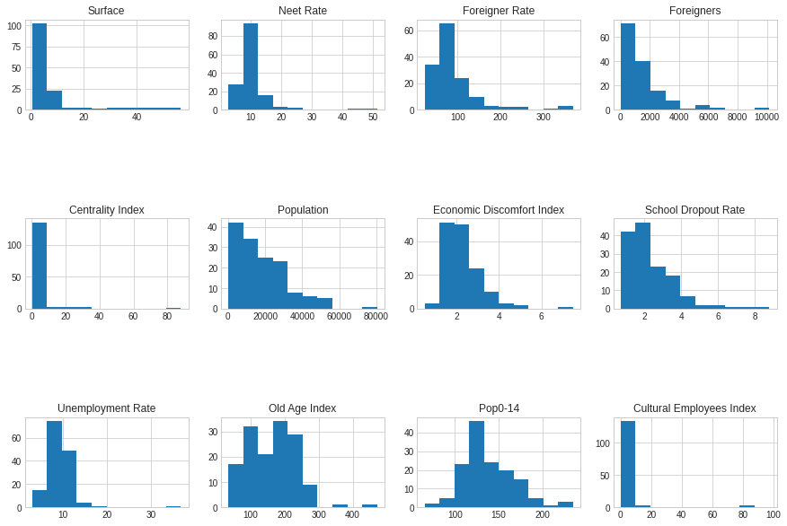

```python
plt.style.use('seaborn-whitegrid')
fig, axes = plt.subplots(figsize=(15,10), nrows=3, ncols=4, gridspec_kw={'hspace':1.2})
for n, feature in enumerate(socio_df.columns):
    i = (n % 3)
    j = (n % 4)
    axes[i,j].hist(socio_df[feature])
    axes[i,j].set_title(feature)
```

#### Observations:

- we see high variability in Size and population
- age indicators are also very variable, with a median of 132 pop 0-14 per 1000 residents, but with minimum of 65 through a maximum of 235. This means we have very young zones beside very old ones
- Economic indicators such as Unemployment Rate, Neet Rate, Economic Discomfort Index, tend to be less dispersed, but show very high spikes that would need some further investigation (left for projects to come...)

#### Geo-visualization of socio-demographic factors

```python
geo_socio_df = gdf.merge(socio_df, how='inner', left_on='Name', right_index=True)
```

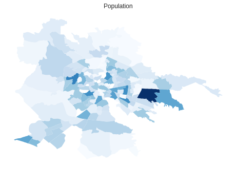

```python
plt.style.use('seaborn-white')
cmap='Blues'
fig = plt.figure(figsize=(8,6))
ax = plt.subplot()
geo_socio_df.plot(column='Population',cmap=cmap, ax=ax)
ax.set_title('Population')
ax.set_axis_off();
```

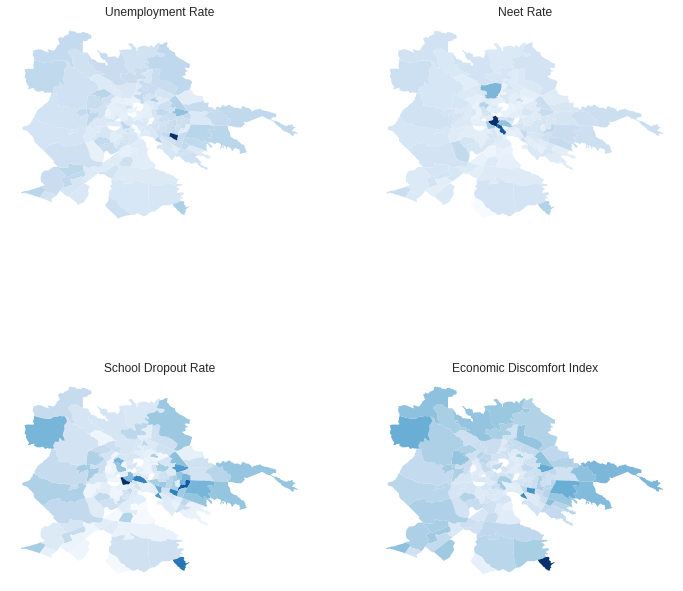

```python
fig, axes = plt.subplots(nrows=2, ncols=2,figsize=(12,12))
for n, feature in enumerate(['Unemployment Rate', 'Neet Rate', 'School Dropout Rate', 'Economic Discomfort Index']):
    i = 0 if n < 2 else 1
    j = 0 if n % 2 == 0 else 1
    geo_socio_df.plot(column=feature,cmap=cmap, ax=axes[i,j])
    axes[i,j].set_title(feature)
    axes[i,j].set_axis_off()
```

#### Observations: economic indicators tend to perform worst on periphery zones, with some interesting exceptions

#### **Venues features**

```python
venues_eda_df = final_df[venues_features]
venues_eda_df.describe()
```

|  | Arts & Entertainment | College & University | Event | Food | Nightlife Spot | Outdoors & Recreation | Professional & Other Places | Residence | Shop & Service | Travel & Transport | Total Venues |
| --- | --- | --- | --- | --- | --- | --- | --- | --- | --- | --- | --- |
| count | 144.00 | 144.00 | 144.00 | 144.00 | 144.00 | 144.00 | 144.00 | 144.00 | 144.00 | 144.00 | 144.00 |
| mean | 0.39 | 0.00 | 0.00 | 2.93 | 0.54 | 0.69 | 0.07 | 0.00 | 0.48 | 0.58 | 5.67 |
| std | 1.78 | 0.00 | 0.00 | 10.79 | 2.18 | 2.30 | 0.33 | 0.01 | 1.02 | 2.05 | 19.14 |
| min | 0.00 | 0.00 | 0.00 | 0.00 | 0.00 | 0.00 | 0.00 | 0.00 | 0.00 | 0.00 | 0.00 |
| 25% | 0.00 | 0.00 | 0.00 | 0.20 | 0.00 | 0.05 | 0.00 | 0.00 | 0.08 | 0.00 | 0.51 |
| 50% | 0.00 | 0.00 | 0.00 | 0.53 | 0.04 | 0.16 | 0.00 | 0.00 | 0.18 | 0.08 | 1.15 |
| 75% | 0.10 | 0.00 | 0.00 | 1.69 | 0.24 | 0.38 | 0.00 | 0.00 | 0.38 | 0.38 | 3.31 |
| max | 14.90 | 0.05 | 0.00 | 108.01 | 20.48 | 18.62 | 3.72 | 0.07 | 9.31 | 20.55 | 186.22 |

#### Observations:

- unfortunately, venues data per macro-category tend to be generally very low. So, we concentrate on "Total Venues" feature

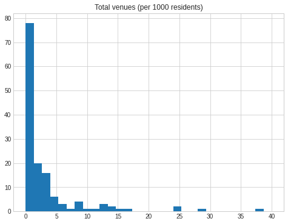

```python
plt.style.use('seaborn-whitegrid')
fig = plt.figure(figsize=(8,6))
ax = plt.subplot()
ax.hist(venues_eda_df['Total Venues'], bins=30, range=(0,40))
ax.set_title('Total venues (per 1000 residents)');
```

#### Geo-visualization of venues features doesn't provide great results, do to the very low data. Nevertheless, we can see higher concentration on central zones (as expected)

```python
geo_venues_df = gdf.merge(venues_eda_df, how='inner', left_on='Name', right_index=True)
```

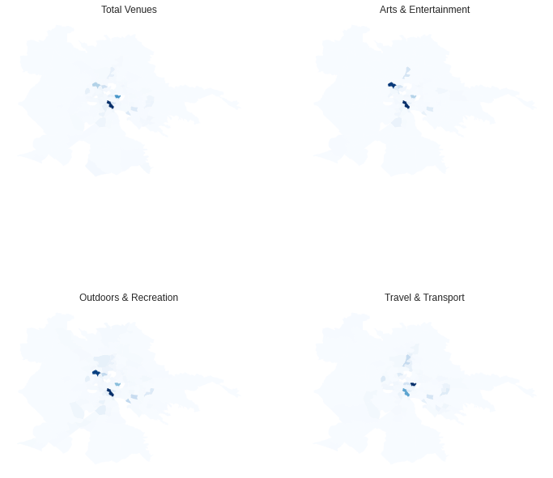

```python
plt.style.use('seaborn-white')
cmap='Blues'
fig, axes = plt.subplots(nrows=2, ncols=2,figsize=(12,12))
for n, feature in enumerate(['Total Venues', 'Arts & Entertainment', 'Outdoors & Recreation', 'Travel & Transport']):
    i = 0 if n < 2 else 1
    j = 0 if n % 2 == 0 else 1
    geo_venues_df.plot(column=feature,cmap=cmap, ax=axes[i,j])
    axes[i,j].set_title(feature)
    axes[i,j].set_axis_off()
```

### **Clustering**

For our main purpose, we choose to implement *clustering* on our zones data set As pre-processing step, we dedice to:

- remove `Latitude`, `Longitude` and `Surface` features, as they are of no interest for this task
- remove `Foreigners` feature, as this feature is collinear with `Foreigner Rate` and `Population`
- perform standardization on remaning features via scikitlearn's Standard Scaler class ((X - $\mu$) / $\sigma$ )

As clustering Algorythm, we decided to use **K-Means** clustering.

In order to find the best number of clusters, we perform 10 runs of clustering, calculate *Inertia* and *Silhouette score* metrics and evaluate results

```python
# remove features
clustering_df = final_df.drop(['Latitude','Longitude','Surface', 'Foreigners'],axis=1)
# feature standard-scaling
StdScaler = StandardScaler()
X = StdScaler.fit_transform(clustering_df)
```

```python
# perform clustering with k = 1..10 and calculate inertia and silhouette
silhouettes = {}
ssqs = {}
for k in range(1, 11):
    kmeans = KMeans(n_clusters = k)
    kmeans.fit(X)
    silhouette = silhouette_score(X, kmeans.labels_) if k > 1 else np.nan
    ssq = kmeans.inertia_
    silhouettes[k] = silhouette
    ssqs[k] = ssq
```

#### Metrics results

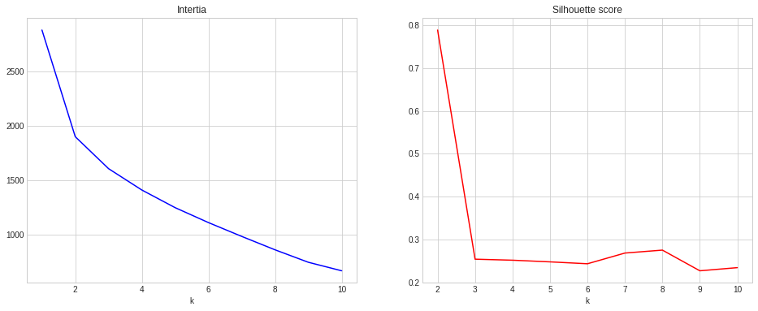

```python
plt.style.use('seaborn-whitegrid')
fig = plt.figure(figsize = (16,6))

ax1 = plt.subplot(121)
ax1.plot(list(ssqs.keys()), list(ssqs.values()), c='b', label='Inertia')
ax1.set_title('Intertia')
ax1.set_xlabel('k')
#ax1.plot(4,ssqs[4],'o',markersize=10)

ax2 = plt.subplot(122)
ax2.plot(list(silhouettes.keys()), list(silhouettes.values()), c='r', label='Silhouette')
ax2.set_title('Silhouette score')
ax2.set_xlabel('k')

plt.show()
```

#### Observations

- Applying the *elbow* method on Inertia plot doesn't provide istantaneous result, but we can say that the optimal number of cluster lies between 2 and 4
- Silhouette scores show that there are 2 clear clusters, but for our purposes this number is too low

Further experiments (we don't show here these results) show that we can choose **3** as the optimal number of cluster, so we go on with clustering our zones in 3 clusters

```python
# leverage tuning parameters for a more stable solution
kmeans = KMeans(n_clusters=3,n_init=30, max_iter=3000, tol=0.00001)
kmeans.fit(X)
clusters = kmeans.labels_
```

```python
# assign cluster labels to observations
final_df['Cluster'] = clusters
```

#### Cluster results

```python
# number of zones per cluster
print('Cluster Id | Nr of zones')
print('------------------------')
for i, c in enumerate(final_df.Cluster.value_counts().sort_index()):
    print('{:10} | {:11}'.format(i, c))
```

```
Cluster Id | Nr of zones
------------------------
         0 |          60
         1 |          81
         2 |           3
```

```python
pd.set_option('display.max_columns',None)
clusters_avgs = final_df.groupby('Cluster').mean()
clusters_avgs = clusters_avgs.merge(final_df.Cluster.value_counts(), left_index=True, right_index=True)
clusters_avgs.rename({'Cluster': 'Nr of Zones'}, inplace=True, axis=1)
```

```python
def highlight_max(s):
    '''
    highlight the maximum in a Series yellow.
    '''
    is_max = s == s.max()
    return ['background-color: yellow' if v and s.name in ['Surface', 'Pop0-14', 'School Dropout Rate','Unemployment Rate', 'Economic Discomfort Index'] else '' for v in is_max ]
```

```python
clusters_avgs[list(social_features) + ['Total Venues','Nr of Zones']].style.apply(highlight_max)
```

|  | Surface | Population | Pop0-14 | Foreigners | Centrality Index | Old Age Index | Foreigner Rate | School Dropout Rate | Unemployment Rate | Neet Rate | Economic Discomfort Index | Cultural Employees Index | Total Venues | Nr of Zones |
| --- | --- | --- | --- | --- | --- | --- | --- | --- | --- | --- | --- | --- | --- | --- |
| 0 | 14.671667 | 14715.450000 | 158.542113 | 1705.100000 | 1.855000 | 107.175000 | 112.001667 | 3.256667 | 10.990000 | 12.666667 | 2.898333 | 3.471667 | 2.110949 | 60 |
| 1 | 3.369136 | 21302.160494 | 124.350715 | 1489.506173 | 2.603704 | 199.029630 | 70.206173 | 1.729630 | 8.222222 | 8.213580 | 1.704938 | 5.035802 | 4.075663 | 81 |
| 2 | 1.633333 | 680.666667 | 85.840113 | 131.666667 | 50.700000 | 324.800000 | 209.066667 | 2.766667 | 5.833333 | 24.866667 | 2.533333 | 86.066667 | 119.732840 | 3 |

#### Observations:

- We can see that our zones are bucked in three distinct groups:
  - "Cluster 0": poor socio-economic indicators and shortage of available venus
  - "Cluster 1": better socio-economic indicators and venues availability
  - "Cluster 2": a very tiny cluster, with only 3 zones with very low population and sufrace and singular behaviour
- For our purposes, we can say that
  - Cluster 2 has no interest, as it's probably composed of singular zones that can be left apart for our analysis
  - Cluster 0 is what we are looking for, as it's a huge cluster of zones sharing these characteristics:
    - High surface
    - Relatively young population
    - Low centrality (periphery zones)
    - School Droput, Unemployment and Economic Discomfort above the mean
    - Venues availability below the mean

#### Let's compare Cluster 0 and Cluster 1 profiles

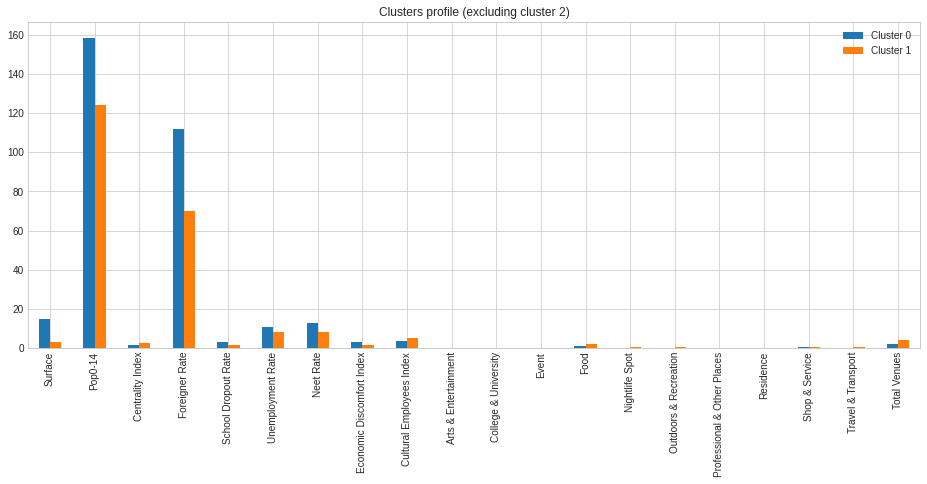

```python
clusters_avgs.loc[[0,1]].drop(['Population', 'Foreigners', 'Latitude', 'Longitude', 'Old Age Index', 'Nr of Zones'],axis=1).transpose().plot(kind='bar',figsize=(16,6))
plt.legend(('Cluster 0', 'Cluster 1'))
plt.title('Clusters profile (excluding cluster 2)');
```

#### The plot confirms our previous observations

#### Geo-visualization of clustering results

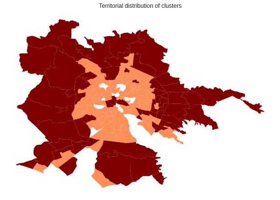

```python
geo_clusters_df = gdf.merge(final_df[['Cluster']],how='inner',left_on='Name', right_index=True)

clusters_centroids = gpd.GeoDataFrame(zip(geo_clusters_df['Cluster'], geo_clusters_df['geometry'].centroid),columns=['Cluster', 'Centroid']).set_geometry('Centroid')

plt.style.use('seaborn-white')
fig = plt.figure(figsize=(10,10))
ax = plt.subplot()
geo_clusters_df.plot(column='Cluster', cmap='OrRd_r', ax=ax)
ax.set_title('Territorial distribution of clusters')
ax.set_axis_off();
```

#### Observation:

- zones in cluster 0 (dark colored) are clearly mostly localized at the periphery of the city

#### Further result: recommended zones to start our customer's project

Having decided to point our attention on Cluster 0, it has to be sad that this is still a huge cluster with 60 zones. So, it's of much interest to find a further criterion to sub-divide cluster 0 and find most interesting zones inside it

This can be a task for other clustering algorythms, such as Hyerarchical (agglomerative) clustering. But for now, we keep it simple: as our customer's target is younger people, we simply sort our cluster on Pop0-14 rate and conclude suggesting the 5 youngest zones

```python
N_RECOMMENDATIONS = 5
recommended_zones = final_df.query('Cluster == 0').sort_values(by='Pop0-14', ascending=False).head(N_RECOMMENDATIONS).index.values
recommended_df = final_df.loc[recommended_zones]
recommended_df
```

| name | Surface | Population | Pop0-14 | Foreigners | Centrality Index | Old Age Index | Foreigner Rate | School Dropout Rate | Unemployment Rate | Neet Rate | Economic Discomfort Index | Cultural Employees Index | Latitude | Longitude | Arts & Entertainment | College & University | Event | Food | Nightlife Spot | Outdoors & Recreation | Professional & Other Places | Residence | Shop & Service | Travel & Transport | Total Venues | Cluster |
| --- | --- | --- | --- | --- | --- | --- | --- | --- | --- | --- | --- | --- | --- | --- | --- | --- | --- | --- | --- | --- | --- | --- | --- | --- | --- | --- |
| S. Alessandro | 11.40 | 9856 | 235.09 | 474 | 0.40 | 36.20 | 48.10 | 1.40 | 6.60 | 8.50 | 2.40 | 2.40 | 41.95 | 12.61 | 0.00 | 0.00 | 0.00 | 0.51 | 0.00 | 0.00 | 0.00 | 0.00 | 0.00 | 0.00 | 0.51 | 0 |
| Magliana | 11.50 | 3803 | 223.24 | 195 | 8.30 | 34.90 | 51.30 | 1.70 | 5.60 | 15.40 | 1.80 | 1.70 | 41.83 | 12.40 | 0.00 | 0.00 | 0.00 | 0.26 | 0.26 | 0.79 | 0.00 | 0.00 | 0.26 | 0.53 | 2.10 | 0 |
| Barcaccia | 5.10 | 10099 | 220.52 | 368 | 0.30 | 42.30 | 36.40 | 1.30 | 7.70 | 7.60 | 2.60 | 0.30 | 41.83 | 12.63 | 0.00 | 0.00 | 0.00 | 0.20 | 0.10 | 0.10 | 0.00 | 0.00 | 0.20 | 0.10 | 0.69 | 0 |
| Infernetto | 11.50 | 24356 | 210.22 | 1750 | 0.20 | 63.60 | 71.90 | 1.10 | 8.00 | 9.60 | 3.10 | 1.50 | 41.74 | 12.37 | 0.00 | 0.00 | 0.00 | 0.25 | 0.00 | 0.04 | 0.00 | 0.00 | 0.08 | 0.00 | 0.37 | 0 |
| Lucrezia Romana | 1.70 | 4451 | 198.38 | 228 | 1.40 | 56.10 | 51.20 | 1.30 | 7.20 | 7.10 | 1.60 | 0.80 | 41.84 | 12.58 | 0.00 | 0.00 | 0.00 | 2.47 | 0.00 | 0.00 | 0.00 | 0.00 | 0.45 | 1.12 | 4.04 | 0 |

#### Where are this zones?

```python
rome_loc = [41.89, 12.48]
rome_map = folium.Map(location=rome_loc,
                      zoom_start=11)

for lat, lon, name in zip(recommended_df['Latitude'], recommended_df['Longitude'], recommended_df.index):
    folium.Marker(
        location = [lat, lon],
        popup = name
    ).add_to(rome_map)

    folium.map.Marker(
    location = [lat, lon-0.02],
    icon=folium.features.DivIcon(
        icon_size=(150,36),
        icon_anchor=(0,0),
        html='<div style="font-size: 11pt">'+name+'</div>',
        )
    ).add_to(rome_map)


rome_map
```

Make this Notebook Trusted to load map: File -> Trust Notebook

[interactive chart not shown]

## **Results**

### As primary result, we identified a main cluster (*Cluster "0"*) of Rome's urbanistic zones (=neighborhoods) which we find particulary suitable for a social center

The 60 zones in this cluster are shown below:

```python
zones_cluster_0 = final_df.query('Cluster == 0').index.values
print("Rome's urbanistic zones in Cluster 0:")
print('\n')
print(', '.join(zones_cluster_0))
```

[output not shown]

#### These are the main statistics on this cluster

```python
final_df.query('Cluster == 0').describe()[1:2] \
 [['Surface','Population', 'Pop0-14','Centrality Index','Foreigner Rate','School Dropout Rate','Unemployment Rate','Neet Rate','Economic Discomfort Index','Total Venues']]
```

|  | Surface | Population | Pop0-14 | Centrality Index | Foreigner Rate | School Dropout Rate | Unemployment Rate | Neet Rate | Economic Discomfort Index | Total Venues |
| --- | --- | --- | --- | --- | --- | --- | --- | --- | --- | --- |
| mean | 14.67 | 14715.45 | 158.54 | 1.85 | 112.00 | 3.26 | 10.99 | 12.67 | 2.90 | 2.11 |

#### Among these 60 zones, we recommend to begin opening social centers in these 5 zones, which show the highest rate of young population:

```python
print('ZONES IN CLUSTER 0 WITH HIGHEST RATE OF YOUNG RESIDENTS:')
print('--------------------------------------------------------')
for z in recommended_zones:
    print(z)
```

```
ZONES IN CLUSTER 0 WITH HIGHEST RATE OF YOUNG RESIDENTS:
--------------------------------------------------------
S. Alessandro
Magliana
Barcaccia
Infernetto
Lucrezia Romana
```

#### And this is the location of these zones

```python
rome_loc = [41.89, 12.48]
rome_map = folium.Map(location=rome_loc,
                      zoom_start=11)

for lat, lon, name in zip(recommended_df['Latitude'], recommended_df['Longitude'], recommended_df.index):
    folium.Marker(
        location = [lat, lon],
        popup = name
    ).add_to(rome_map)

    folium.map.Marker(
    location = [lat, lon-0.02],
    icon=folium.features.DivIcon(
        icon_size=(150,36),
        icon_anchor=(0,0),
        html='<div style="font-size: 11pt">'+name+'</div>',
        )
    ).add_to(rome_map)


rome_map
```

Make this Notebook Trusted to load map: File -> Trust Notebook

[interactive chart not shown]

## **Discussion**

There are some points of improvement that are wortn-noting:

- First of all, we can retrieve **more data on economic factors**. For example, scraping from www.mercato-immobiliare.info (a web-site providing house prices for Italy at a very fine-grained territorial level) we can retrive sales price and rent price for houses and apartements. The code for scraping this site (based on BeautifulSoup) is provided as an example in the next cell
- As stated in Methodology section, our Cluster 0 is still a very big cluster, with 60 zones. We can try an **alternative clustering approach**, such as Hyerarchical agglomerative clustering in order to find more narrow clusters where to point our attention
- The choice of top 5 recommended zones was done based on **arbitraty sorting by youth rate**. We can think about a better criterion
- Clustering algorythms don't tell us the whole story. It would be very interesting (especially when more features will become available) to implement some analytic technique which can provide more insights. A good candidate in **Factor Analysis**, which can be useful in finding hidden factors describing our data
- scraping venues data from Foursquare hasn't provided great results. We can try with **other sources of venues data**, such as Google's

```python
###############################################################
## EXAMPLE CODE FOR SCRAPING APARTMENTS SALES AND RENT PRICES##
##             (data not used in this project)               ##
###############################################################
url = 'https://www.mercato-immobiliare.info/lazio/roma/roma/quotazione-appartamento.html'

soup = BeautifulSoup(requests.get(url).content)

table = soup.find_all('table')[0]

apartments_df = pd.DataFrame(columns=['name','latitude','longitude','sale_price','rent_price'])

for tr in table.find_all('tr')[1:]:
    dict_row = {}
    tds = tr.find_all('td')

    name  = tds[1].find_all('a')[0].text
    dict_row['name'] = name

    location = tds[0].find_all('a')[0]['href']
    latitude = float(re.search('https://maps\.google\.it/\?q\=(.*)\%', location).group(1))
    longitude = float(re.search('https://maps\.google\.it/\?q\=[\d]+.[\d]+\%2C(.*)', location).group(1))
    dict_row['latitude'] = latitude
    dict_row['longitude'] = longitude

    price = float(tds[2].text.replace('€','').replace('/m²','').replace('.','').strip())
    dict_row['sale_price'] = price

    rent = tds[3].text.replace('€','').replace('/m²/mese','').replace('.','').replace(',','.') if tds[3].text != '-' else np.nan
    dict_row['rent_price'] = rent

    apartments_df = apartments_df.append(dict_row, ignore_index = True)
```

## **Conclusions**

In this project we were able to identify a big cluster of neighborhoods in the city of Rome where the need for a social center is particularly high.

We scraped data from a paper published by Italian Institute of Statistics (Istat) to retrieve socio-demographic information on the 155 Urbanistic zones, using *tabula-py* Python library for pdf scraping, and retrieved informations on venues available in each zone using Fousquare `explore` APIs. Furthermore, we used shapefiles from www.mapparoma.info, *geopandas* and *folium* Python libraries to geo-locate the zones and display geo-located results

We applied *k-means* cluster analysis using scikitlearn's *cluster* module as clustering algorythm and grouped Rome's neighbohoods in 3 clusters. One of these clusters (*"Cluster 0"*) was identified as the most suited for our customer's purpose

Finally, we selected the 5 most suitable zones among *Cluster 0* by simply sorting by youth rate, and provide this zones as recommended zones where to start-up our customer's project

In the discussion section, we also provided suggestions for further development and investigation

## **Refences/acknowledgments**

Istituto nazionale di statistica: www.istat.it

Mapparoma: https://www.mapparoma.info/

On cluster analyses: https://en.wikipedia.org/wiki/Cluster_analysis

gitHub repo of this project: https://github.com/MicheleGava/battle_of_neighborhoods_w1